# Prévalence de l’anémie au Burkina Faso (EDS 2010)

Seydou TOGUIYENI, Cohorte 3

Final project, 2023-12-22

# 1 Introduction

Notre analyse porte sur la *prévalence de l’anémie*. Les données proviennent de la base de données de l’EDS 2010 du Burkina Faso.

Selon la méthodologie de l’enquête EDS, l’anémie est évalué sur les 1/2 des ménages de l’échantillon. Un prélevenement de sang est effectué sur obtention de consentement.

L’analyse de la prévalence est présenté selon certaines caractéristiques socio-demographiques. Les étapes d’analyses ont été successivement :

- L’import de la base de données avec selections des variables d’interet
- La selection des menages avec consentement de l’évaluation de l’anémie
- L’analyse de la prévalence

# 2 Prévalence de l’anémie

Au Burkina Faso, sur l’échantillon des **8.376** dont l’anémie a été évalué, la prévalence de l’anemie était de `48 %` dont `33%` d’anémie légère et `1%` d’anémie sévère

Distribution of anemia

| anemia_level | n | percent |
| --- | --- | --- |
| severe | 89 | 0.0106256 |
| moderate | 1154 | 0.1377746 |
| mild | 2790 | 0.3330946 |
| not anemic | 4343 | 0.5185053 |

# 3 Prévalence de l’anémie selon l’age et le sexe

la figure ci-dessous permet d’observer que piur chaque niveau de severite de l’anemie, la moyenne d’age est entre 25-30 ans quelque soit le sexe et 75% des cas d’anemeie ont un age presque inferieur à 35 ans. Cependant une différence selon le sexe est observé pour les cas d’anemie severe.

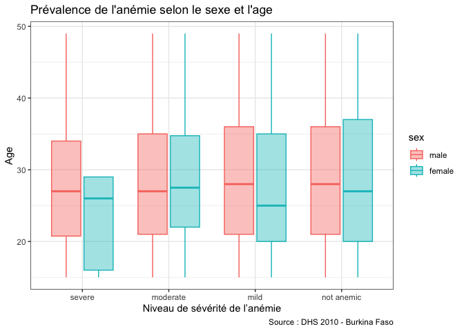

# 4 Prévalence de l’anémie selon les regions

La prévalence de l’anémie est superieure à 50% dans 4 sur 13 régions. la region du sahel a la plus forte prévalence dont 68%, suivi des régions des cascades, de l’Est et du Centre-ouest. L’anemie severe est plus élévé également dans la région du sahel avec près de 3%.

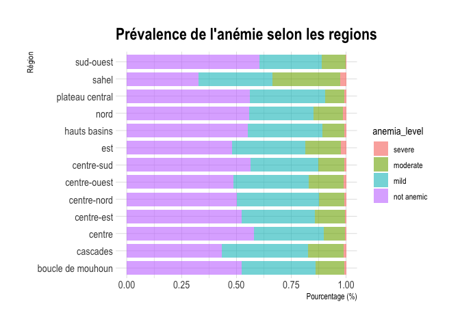

# 5 Prévalence de l’anemie selon le niveau de vie

La severite de l’anemie est inversement proportionnel au niveau de vie. La même tendance est observé selon le milieu de residence (urbain / rural). Cependant l’anemie est plus present en milieu rural. En milieu urbain, la prévalence de l’anémie est inférieur à 50% quelque soit le niveau de vie

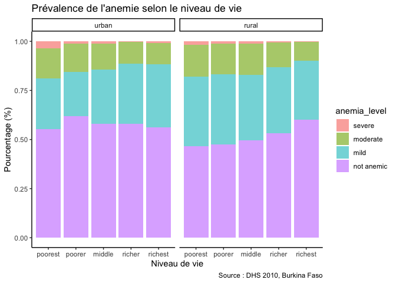

# 6 Prévalence de l’anemie selon le nombre d’enfants dans le ménage

le nombre d’enfant dans le ménage semble ne pas avoir d’influence sur la sévérité de l’anemie

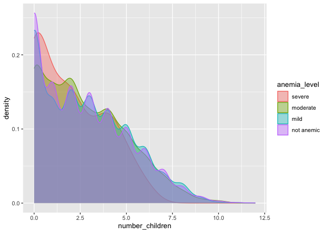

# 7 Annexe

Tableau récapitulatif du niveau de severité de l’anémie

Prévalence de l'anemie selon les caractéristiques socio-demographique

|  | severe (N=89) | moderate (N=1154) | mild (N=2790) | not anemic (N=4343) | Overall (N=8376) |
| --- | --- | --- | --- | --- | --- |
| sex of household head |  |  |  |  |  |
| male | 84 (94.4%) | 1052 (91.2%) | 2499 (89.6%) | 3820 (88.0%) | 7455 (89.0%) |
| female | 5 (5.6%) | 102 (8.8%) | 291 (10.4%) | 523 (12.0%) | 921 (11.0%) |
| age in 5-year groups |  |  |  |  |  |
| 15-19 | 22 (24.7%) | 213 (18.5%) | 547 (19.6%) | 861 (19.8%) | 1643 (19.6%) |
| 20-24 | 12 (13.5%) | 238 (20.6%) | 512 (18.4%) | 827 (19.0%) | 1589 (19.0%) |
| 25-29 | 20 (22.5%) | 203 (17.6%) | 475 (17.0%) | 764 (17.6%) | 1462 (17.5%) |
| 30-34 | 16 (18.0%) | 182 (15.8%) | 433 (15.5%) | 650 (15.0%) | 1281 (15.3%) |
| 35-39 | 7 (7.9%) | 136 (11.8%) | 329 (11.8%) | 521 (12.0%) | 993 (11.9%) |
| 40-44 | 5 (5.6%) | 112 (9.7%) | 265 (9.5%) | 377 (8.7%) | 759 (9.1%) |
| 45-49 | 7 (7.9%) | 70 (6.1%) | 229 (8.2%) | 343 (7.9%) | 649 (7.7%) |
| type of place of residence |  |  |  |  |  |
| urban | 22 (24.7%) | 292 (25.3%) | 805 (28.9%) | 1470 (33.8%) | 2589 (30.9%) |
| rural | 67 (75.3%) | 862 (74.7%) | 1985 (71.1%) | 2873 (66.2%) | 5787 (69.1%) |
| region |  |  |  |  |  |
| boucle de mouhoun | 6 (6.7%) | 93 (8.1%) | 237 (8.5%) | 370 (8.5%) | 706 (8.4%) |
| cascades | 6 (6.7%) | 87 (7.5%) | 212 (7.6%) | 232 (5.3%) | 537 (6.4%) |
| centre | 5 (5.6%) | 77 (6.7%) | 253 (9.1%) | 463 (10.7%) | 798 (9.5%) |
| centre-est | 4 (4.5%) | 83 (7.2%) | 203 (7.3%) | 317 (7.3%) | 607 (7.2%) |
| centre-nord | 5 (5.6%) | 66 (5.7%) | 215 (7.7%) | 289 (6.7%) | 575 (6.9%) |
| centre-ouest | 8 (9.0%) | 122 (10.6%) | 261 (9.4%) | 370 (8.5%) | 761 (9.1%) |
| centre-sud | 5 (5.6%) | 63 (5.5%) | 168 (6.0%) | 305 (7.0%) | 541 (6.5%) |
| est | 15 (16.9%) | 110 (9.5%) | 222 (8.0%) | 322 (7.4%) | 669 (8.0%) |
| hauts basins | 6 (6.7%) | 81 (7.0%) | 268 (9.6%) | 439 (10.1%) | 794 (9.5%) |
| nord | 9 (10.1%) | 86 (7.5%) | 191 (6.8%) | 359 (8.3%) | 645 (7.7%) |
| plateau central | 5 (5.6%) | 54 (4.7%) | 209 (7.5%) | 342 (7.9%) | 610 (7.3%) |
| sahel | 14 (15.7%) | 167 (14.5%) | 183 (6.6%) | 176 (4.1%) | 540 (6.4%) |
| sud-ouest | 1 (1.1%) | 65 (5.6%) | 168 (6.0%) | 359 (8.3%) | 593 (7.1%) |
| highest educational level |  |  |  |  |  |
| no education | 75 (84.3%) | 918 (79.5%) | 2063 (73.9%) | 3048 (70.2%) | 6104 (72.9%) |
| primary | 5 (5.6%) | 131 (11.4%) | 383 (13.7%) | 684 (15.7%) | 1203 (14.4%) |
| secondary | 9 (10.1%) | 99 (8.6%) | 326 (11.7%) | 570 (13.1%) | 1004 (12.0%) |
| higher | 0 (0%) | 6 (0.5%) | 14 (0.5%) | 41 (0.9%) | 61 (0.7%) |
| 9 | 0 (0%) | 0 (0%) | 4 (0.1%) | 0 (0%) | 4 (0.0%) |
| wealth index |  |  |  |  |  |
| poorest | 27 (30.3%) | 236 (20.5%) | 517 (18.5%) | 687 (15.8%) | 1467 (17.5%) |
| poorer | 20 (22.5%) | 241 (20.9%) | 538 (19.3%) | 752 (17.3%) | 1551 (18.5%) |
| middle | 17 (19.1%) | 249 (21.6%) | 515 (18.5%) | 796 (18.3%) | 1577 (18.8%) |
| richer | 9 (10.1%) | 208 (18.0%) | 560 (20.1%) | 936 (21.6%) | 1713 (20.5%) |
| richest | 16 (18.0%) | 220 (19.1%) | 660 (23.7%) | 1172 (27.0%) | 2068 (24.7%) |